# Final Project Appendix

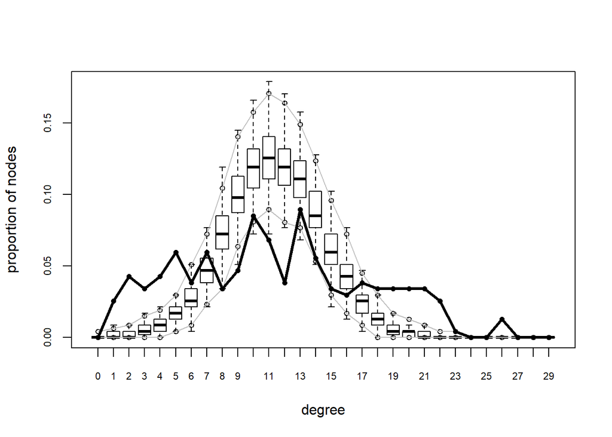

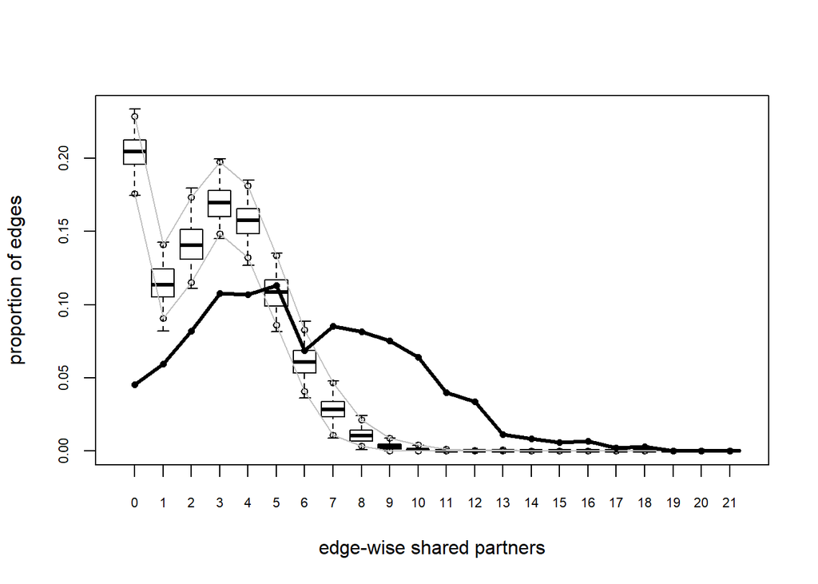

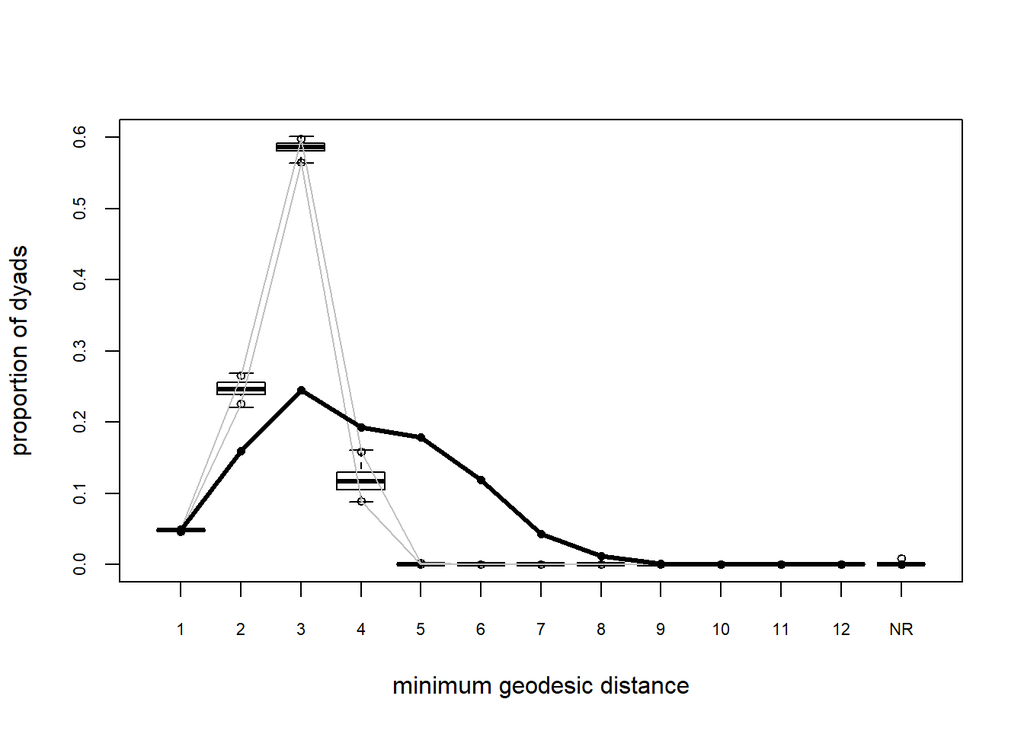

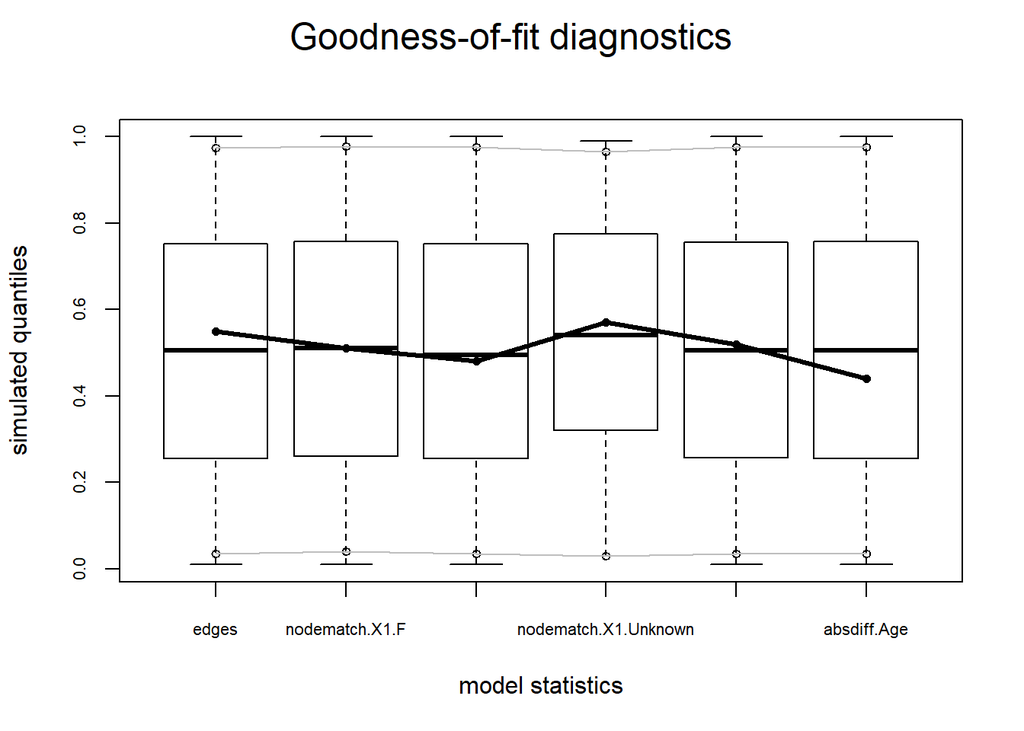

```r
plot(ga_2.m5.gof)
```

### Model 6 MCMC statistics have high correlations, and joint p-value is also 0.

```r
## ga_2.m6 <- ergm(ga_2.net ~ edges + nodematch("X1", diff = T) +
##                   nodematch("X0") + absdiff("Age")+degree(1:5),
##                 control=control.ergm(MCMC.burnin = 100000,MCMC.interval = 5000))
## ga_2.m6.gof <- gof(ga_2.m6)
summary(ga_2.m6)
```

```
##
## ==========================
## Summary of model fit
## ==========================
##
## Formula:   ga_2.net ~ edges + nodematch("X1", diff = T) + nodematch("X0") +
##     absdiff("Age") + degree(1:5)
##
## Iterations:  20 out of 20
##
## Monte Carlo MLE Results:
##                      Estimate Std. Error MCMC % p-value
## edges                -1.44779    0.02836      0  <1e-04 ***
## nodematch.X1.F        0.32826    0.03589      0  <1e-04 ***
## nodematch.X1.M        0.46388    0.03680      0  <1e-04 ***
## nodematch.X1.Unknown -0.01960    0.24919      1   0.937
## nodematch.X0          2.87234    0.05881      1  <1e-04 ***
## absdiff.Age           0.20200    0.00702      0  <1e-04 ***
## degree1              15.87292         NA     NA      NA
## degree2              17.96196         NA     NA      NA
## degree3              12.06530         NA     NA      NA
## degree4               9.02377         NA     NA      NA
## degree5               4.53998         NA     NA      NA
## ---
## Signif. codes:  0 '***' 0.001 '**' 0.01 '*' 0.05 '.' 0.1 ' ' 1
##
##      Null Deviance: 38116  on 27495  degrees of freedom
##  Residual Deviance: 21444  on 27484  degrees of freedom
##
## AIC: 21466    BIC: 21556    (Smaller is better.)
```

```r
mcmc.diagnostics(ga_2.m6)
```

```
## Sample statistics summary:
##
## Iterations = 1e+05:5215000
## Thinning interval = 5000
## Number of chains = 1
## Sample size per chain = 1024
##
## 1. Empirical mean and standard deviation for each variable,
##    plus standard error of the mean:
##
##                          Mean      SD Naive SE Time-series SE
## edges                 8671.02  71.864   2.2458          5.967
## nodematch.X1.F        1989.81  34.564   1.0801          2.809
## nodematch.X1.M        2035.56  34.482   1.0776          2.926
## nodematch.X1.Unknown    53.56   4.058   0.1268          0.412
## nodematch.X0          1082.63  18.173   0.5679          2.341
## absdiff.Age          20157.12 224.372   7.0116         21.714
## degree1                 -6.00   0.000   0.0000          0.000
## degree2                -10.00   0.000   0.0000          0.000
## degree3                 -8.00   0.000   0.0000          0.000
## degree4                -10.00   0.000   0.0000          0.000
## degree5                -14.00   0.000   0.0000          0.000
##
## 2. Quantiles for each variable:
##
##                       2.5%   25%   50%   75% 97.5%
## edges                 8524  8626  8670  8718  8813
## nodematch.X1.F        1918  1967  1992  2015  2054
## nodematch.X1.M        1965  2014  2037  2060  2097
## nodematch.X1.Unknown    45    51    54    56    61
## nodematch.X0          1050  1070  1082  1095  1120
## absdiff.Age          19718 20011 20151 20310 20589
## degree1                 -6    -6    -6    -6    -6
## degree2                -10   -10   -10   -10   -10
## degree3                 -8    -8    -8    -8    -8
## degree4                -10   -10   -10   -10   -10
## degree5                -14   -14   -14   -14   -14
##
##
## Sample statistics cross-correlations:
```

```
##                          edges nodematch.X1.F nodematch.X1.M
## edges                1.0000000    0.506013821     0.50352757
## nodematch.X1.F       0.5060138    1.000000000     0.01715936
## nodematch.X1.M       0.5035276    0.017159359     1.00000000
## nodematch.X1.Unknown 0.0521729   -0.002297513     0.03169561
## nodematch.X0         0.2109071    0.073681715     0.16862869
## absdiff.Age          0.7277478    0.337087535     0.23001722
## degree1                     NA             NA             NA
## degree2                     NA             NA             NA
## degree3                     NA             NA             NA
## degree4                     NA             NA             NA
## degree5                     NA             NA             NA
##                      nodematch.X1.Unknown nodematch.X0 absdiff.Age degree1
## edges                         0.052172899   0.21090710  0.72774784      NA
## nodematch.X1.F               -0.002297513   0.07368172  0.33708753      NA
## nodematch.X1.M                0.031695606   0.16862869  0.23001722      NA
## nodematch.X1.Unknown          1.000000000   0.03852014  0.09121932      NA
## nodematch.X0                  0.038520143   1.00000000 -0.01723911      NA
## absdiff.Age                   0.091219319  -0.01723911  1.00000000      NA
## degree1                                NA           NA          NA       1
## degree2                                NA           NA          NA      NA
## degree3                                NA           NA          NA      NA
## degree4                                NA           NA          NA      NA
## degree5                                NA           NA          NA      NA
##                      degree2 degree3 degree4 degree5
## edges                     NA      NA      NA      NA
## nodematch.X1.F            NA      NA      NA      NA
## nodematch.X1.M            NA      NA      NA      NA
## nodematch.X1.Unknown      NA      NA      NA      NA
## nodematch.X0              NA      NA      NA      NA
## absdiff.Age               NA      NA      NA      NA
## degree1                   NA      NA      NA      NA
## degree2                    1      NA      NA      NA
## degree3                   NA       1      NA      NA
## degree4                   NA      NA       1      NA
## degree5                   NA      NA      NA       1
##
## Sample statistics auto-correlation:
## Chain 1
##               edges nodematch.X1.F nodematch.X1.M nodematch.X1.Unknown
## Lag 0     1.0000000      1.0000000      1.0000000            1.0000000
## Lag 5000  0.7516683      0.7422407      0.7609935            0.8267206
## Lag 10000 0.5801770      0.5547542      0.5915540            0.6732658
## Lag 15000 0.4603087      0.4180819      0.4811029            0.5453079
## Lag 20000 0.3534212      0.3060658      0.3883866            0.4302482
## Lag 25000 0.2528577      0.2418055      0.3192034            0.3312220
##           nodematch.X0 absdiff.Age degree1 degree2 degree3 degree4 degree5
## Lag 0        1.0000000   1.0000000     NaN     NaN     NaN     NaN     NaN
## Lag 5000     0.8887010   0.8109793     NaN     NaN     NaN     NaN     NaN
## Lag 10000    0.7866424   0.6571145     NaN     NaN     NaN     NaN     NaN
## Lag 15000    0.7021136   0.5371072     NaN     NaN     NaN     NaN     NaN
## Lag 20000    0.6355066   0.4372619     NaN     NaN     NaN     NaN     NaN
## Lag 25000    0.5818446   0.3511194     NaN     NaN     NaN     NaN     NaN
##
## Sample statistics burn-in diagnostic (Geweke):
```

```
## Chain 1
##
## Fraction in 1st window = 0.1
## Fraction in 2nd window = 0.5
##
##                edges       nodematch.X1.F       nodematch.X1.M
##               1.5226               0.3117               2.5783
## nodematch.X1.Unknown         nodematch.X0          absdiff.Age
##               1.1857               0.4955               0.9459
##              degree1              degree2              degree3
##                  NaN                  NaN                  NaN
##              degree4              degree5
##                  NaN                  NaN
##
## Individual P-values (lower = worse):
##                edges       nodematch.X1.F       nodematch.X1.M
##          0.127862755          0.755244733          0.009928507
## nodematch.X1.Unknown         nodematch.X0          absdiff.Age
##          0.235735400          0.620244055          0.344178144
##              degree1              degree2              degree3
##                  NaN                  NaN                  NaN
##              degree4              degree5
##                  NaN                  NaN
## Joint P-value (lower = worse):  0 .
```

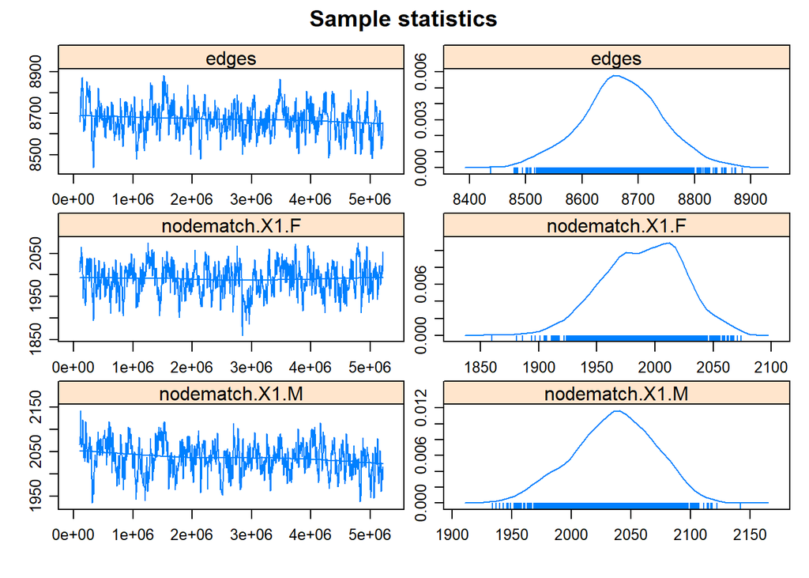

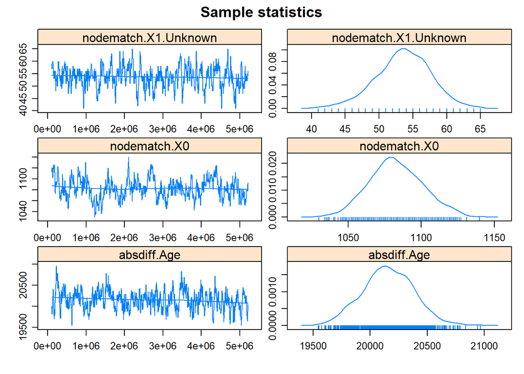

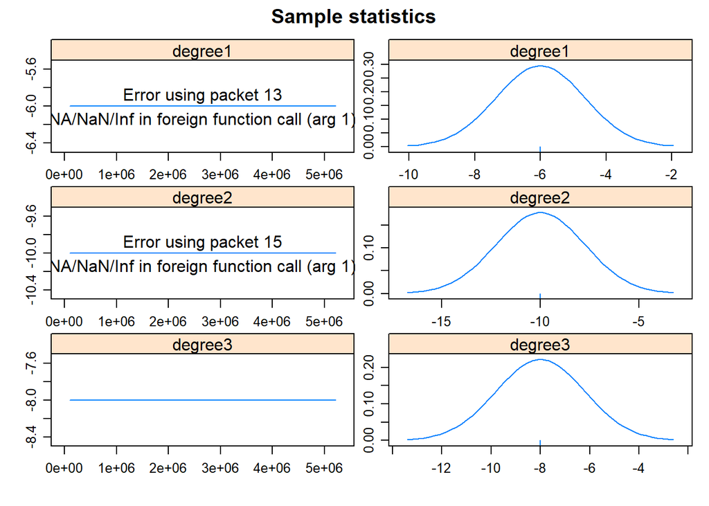

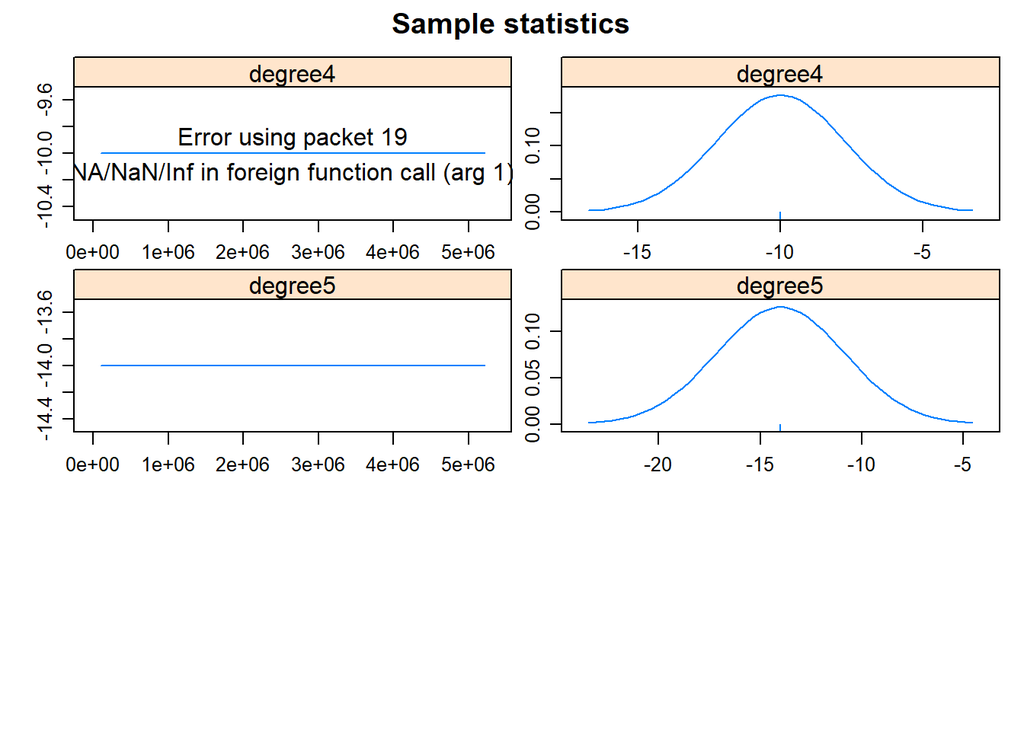

[output not shown]

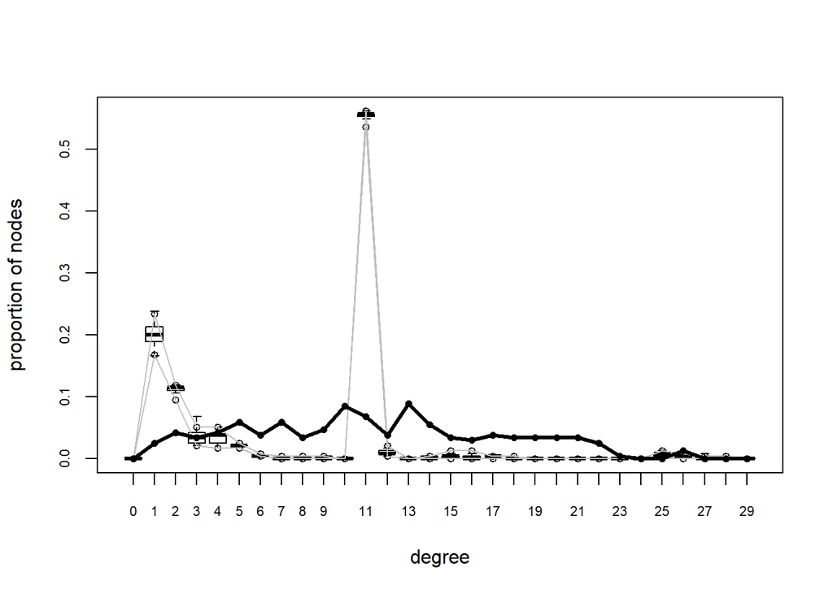

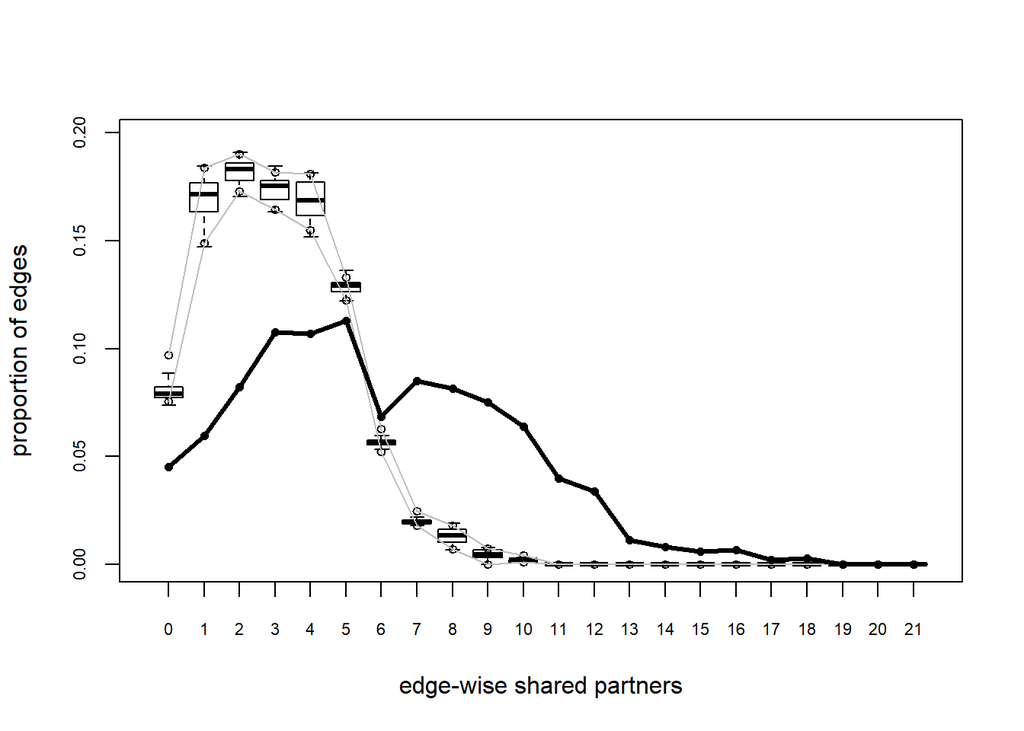

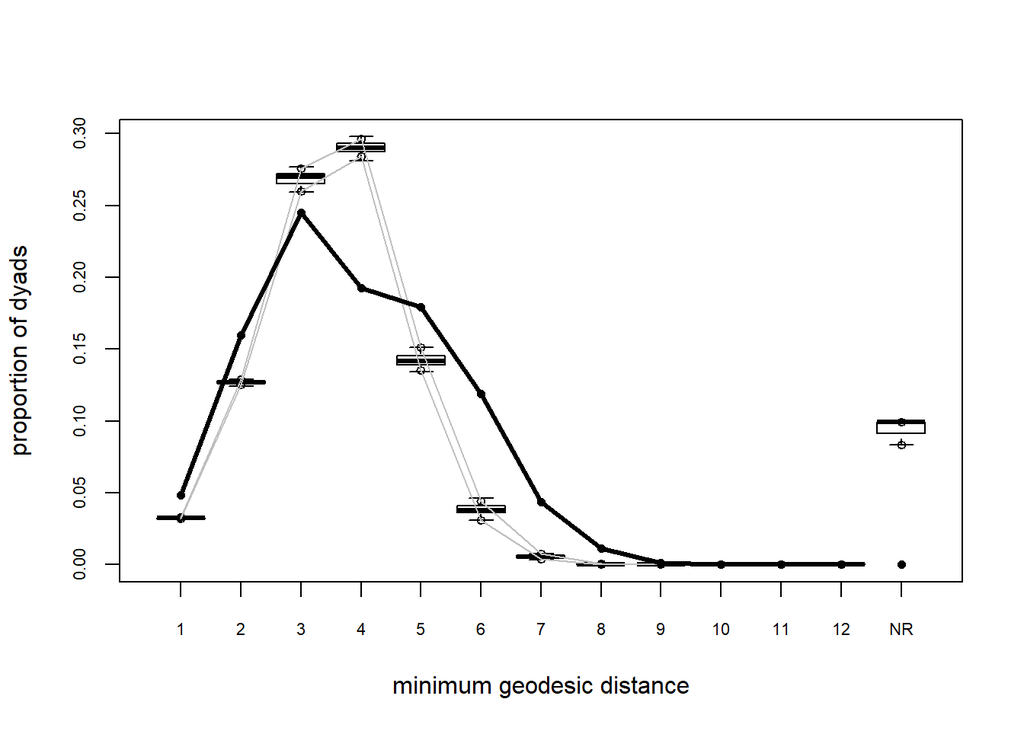

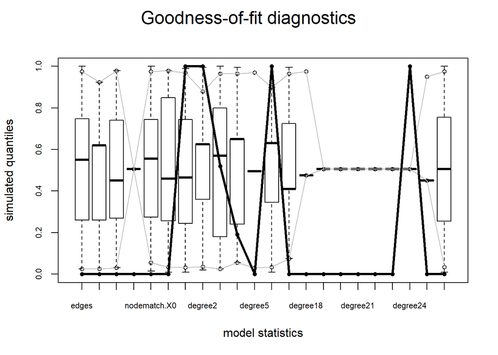

```r
plot(ga_2.m6.gof)
```

### Model 7 Still the model does not perform well with updated degree

```r
## ga_2.m7 <- ergm(ga_2.net ~ edges + nodematch("X1", diff = T) +
##                  nodematch("X0") + absdiff("Age")+degree(1:3)+ gwesp(0.25, fixed = T))
## ga_2.m7.gof <- gof(ga_2.m7)

summary(ga_2.m7)
```

```
##
## ==========================
## Summary of model fit
## ==========================
##
## Formula:   ga_2.net ~ edges + nodematch("X1", diff = T) + nodematch("X0") +
##     absdiff("Age") + degree(1:3) + gwesp(0.25, fixed = T)
##
## Iterations:  20 out of 20
##
## Monte Carlo MLE Results:
##                       Estimate Std. Error MCMC % p-value
## edges                100.92368    0.76745      0  <1e-04 ***
## nodematch.X1.F       -14.39717    0.47522      2  <1e-04 ***
## nodematch.X1.M        -9.95276    0.28433      4  <1e-04 ***
## nodematch.X1.Unknown  10.45895    5.90279      1  0.0764 .
## nodematch.X0           0.07386    0.21593      3  0.7323
## absdiff.Age          -30.10102    0.16209      3  <1e-04 ***
## degree1              293.97616    2.58069      2  <1e-04 ***
## degree2              190.52786    2.44390      2  <1e-04 ***
## degree3               78.92477    7.25561      0  <1e-04 ***
## gwesp.fixed.0.25       1.37738    0.55530      0  0.0131 *
## ---
## Signif. codes:  0 '***' 0.001 '**' 0.01 '*' 0.05 '.' 0.1 ' ' 1
##
##      Null Deviance:  38116  on 27495  degrees of freedom
##  Residual Deviance: 749561  on 27485  degrees of freedom
##
## AIC: 749581    BIC: 749663    (Smaller is better.)
```

```r
mcmc.diagnostics(ga_2.m7)
```

```
## Sample statistics summary:
##
## Iterations = 16384:1063936
## Thinning interval = 1024
## Number of chains = 1
## Sample size per chain = 1024
##
## 1. Empirical mean and standard deviation for each variable,
##    plus standard error of the mean:
##
##                          Mean       SD  Naive SE Time-series SE
## edges                1592.296 251.9596  7.873739      1.950e+02
## nodematch.X1.F       -279.420  23.3252  0.728912      1.709e+01
## nodematch.X1.M       1660.910   6.0511  0.189096      1.916e+00
## nodematch.X1.Unknown   -2.952   0.2435  0.007609      5.940e-02
## nodematch.X0         -475.146  44.7189  1.397465      3.030e+01
## absdiff.Age          2886.300 342.8155 10.712983      2.699e+02
## degree1                92.493   2.2645  0.070766      1.592e-01
## degree2                47.561   4.2033  0.131354      2.025e+00
## degree3                -4.979   0.1451  0.004533      5.369e-03
## gwesp.fixed.0.25     2018.375 325.7808 10.180649      2.513e+02
##
## 2. Quantiles for each variable:
##
##                      2.5%  25%  50%  75%  97.5%
## edges                1223 1406 1561 1797 2095.3
## nodematch.X1.F       -310 -297 -285 -265 -231.0
## nodematch.X1.M       1649 1656 1662 1666 1671.0
## nodematch.X1.Unknown   -3   -3   -3   -3   -2.0
## nodematch.X0         -551 -505 -469 -444 -387.6
## absdiff.Age          2383 2634 2852 3172 3567.4
## degree1                89   91   92   94   97.0
## degree2                40   44   48   51   55.0
## degree3                -5   -5   -5   -5   -5.0
## gwesp.fixed.0.25     1541 1775 1977 2283 2669.9
##
##
## Sample statistics cross-correlations:
##                            edges nodematch.X1.F nodematch.X1.M
## edges                 1.00000000     0.99132684    -0.12526221
```

[output cut: 42 more lines]

```
## Lag 0       1.0000000   1.0000000 1.0000000 1.0000000  1.00000000
## Lag 1024    0.9957502   0.9968509 0.6612215 0.8981141  0.25673777
## Lag 2048    0.9915909   0.9936874 0.4575008 0.8353756 -0.02199897
## Lag 3072    0.9874383   0.9904848 0.3161060 0.7912070 -0.02202041
## Lag 4096    0.9832946   0.9872869 0.1794769 0.7482556 -0.02204185
## Lag 5120    0.9790890   0.9840394 0.1266253 0.7300598  0.02438925
##          gwesp.fixed.0.25
## Lag 0           1.0000000
## Lag 1024        0.9967200
## Lag 2048        0.9934507
## Lag 3072        0.9901912
## Lag 4096        0.9869426
## Lag 5120        0.9836766
##
## Sample statistics burn-in diagnostic (Geweke):
```

```
## Chain 1
##
## Fraction in 1st window = 0.1
## Fraction in 2nd window = 0.5
##
##                edges       nodematch.X1.F       nodematch.X1.M
##              -4.2059              -3.7005               1.2851
## nodematch.X1.Unknown         nodematch.X0          absdiff.Age
##              -0.8431              -6.4607              -3.9156
##              degree1              degree2              degree3
##               2.1624               8.9570              -0.4088
##     gwesp.fixed.0.25
##              -4.2399
##
## Individual P-values (lower = worse):
##                edges       nodematch.X1.F       nodematch.X1.M
##         2.600980e-05         2.152092e-04         1.987610e-01
## nodematch.X1.Unknown         nodematch.X0          absdiff.Age
##         3.991559e-01         1.042219e-10         9.019679e-05
##              degree1              degree2              degree3
##         3.058421e-02         3.336467e-19         6.826770e-01
##     gwesp.fixed.0.25
##         2.236109e-05
## Joint P-value (lower = worse):  0 .
```

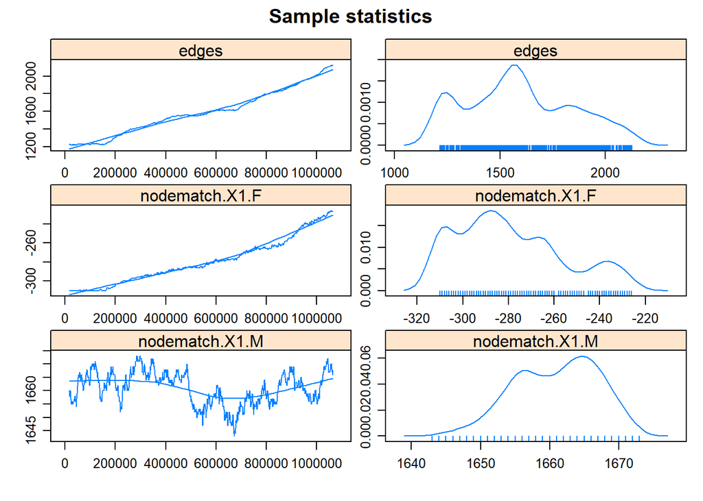

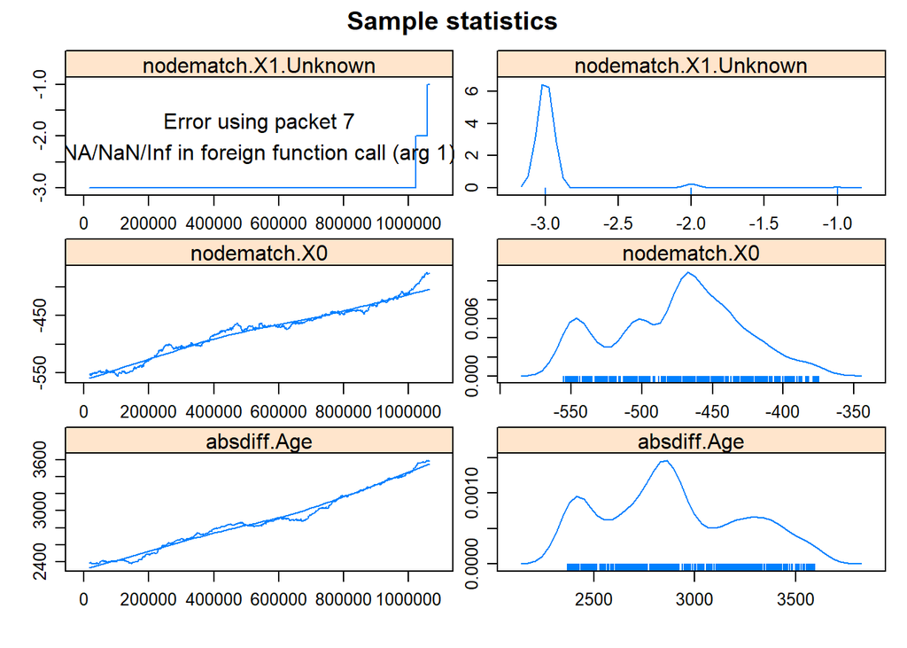

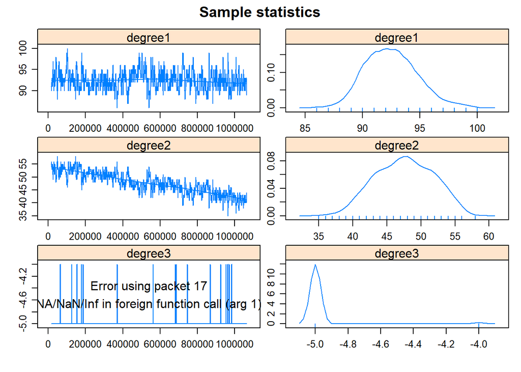

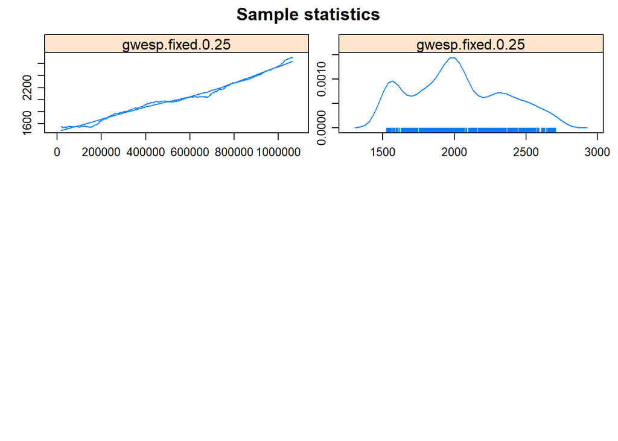

[output not shown]

```r
## plot(ga_2.m7.gof)
```

### CUG test

High Assortativity on both Grade and Gender attributes. The Grade has higher assortativity so the assortativity is higher than random generated graphs.

```r
# CUG test
attr.sex <- as.factor(V(giant_1)$X0)
attr.grade <- as.factor(V(giant_1)$Grade)
assortativity(giant_1,types1 = attr.sex)
```

```
## [1] 0.8271385
```

```r
assortativity(giant_1,types1 = attr.grade)
```

```
## [1] 0.9335869
```

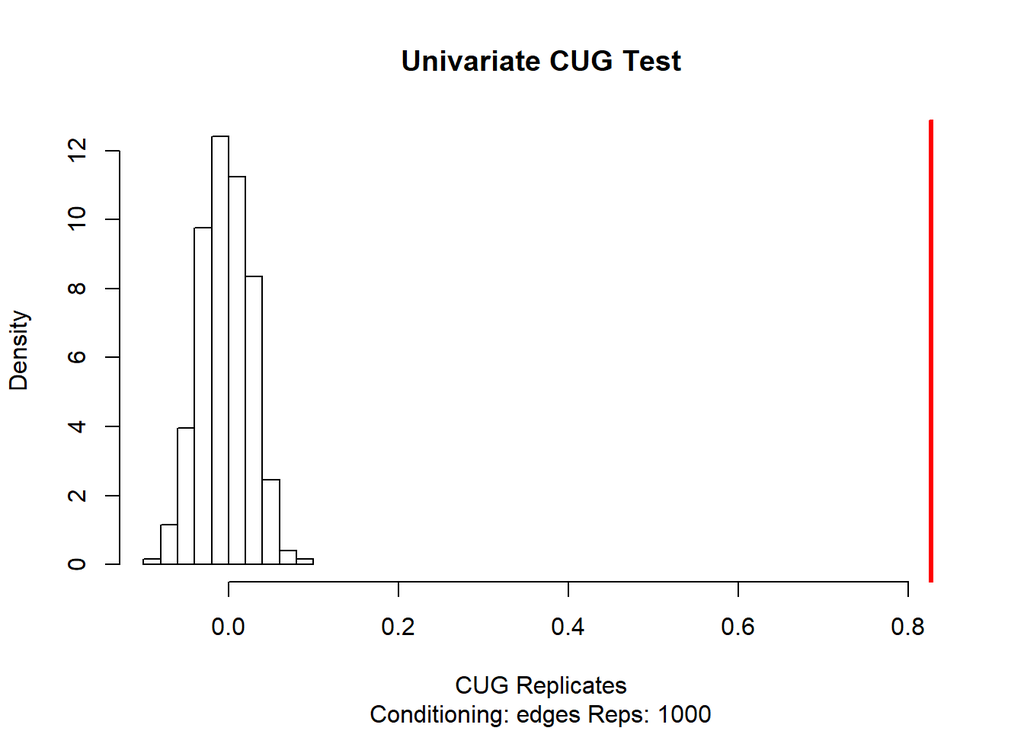

```r
sex.cug <- mycugtest(giant_1, assortativity, cmode = "edges",
                      types1=attr.sex)
grade.cug <- mycugtest(giant_1, assortativity, cmode = "edges",
                     types1=attr.grade)

plot.cug.test(sex.cug)
```

```r
print.cug.test(sex.cug)
```

```
##
## Univariate Conditional Uniform Graph Test
##
## Conditioning Method: edges
## Graph Type:
## Diagonal Used: FALSE
## Replications: 1000
##
## Observed Value: 0.8271385
## Pr(X>=Obs): 0
## Pr(X<=Obs): 1
```

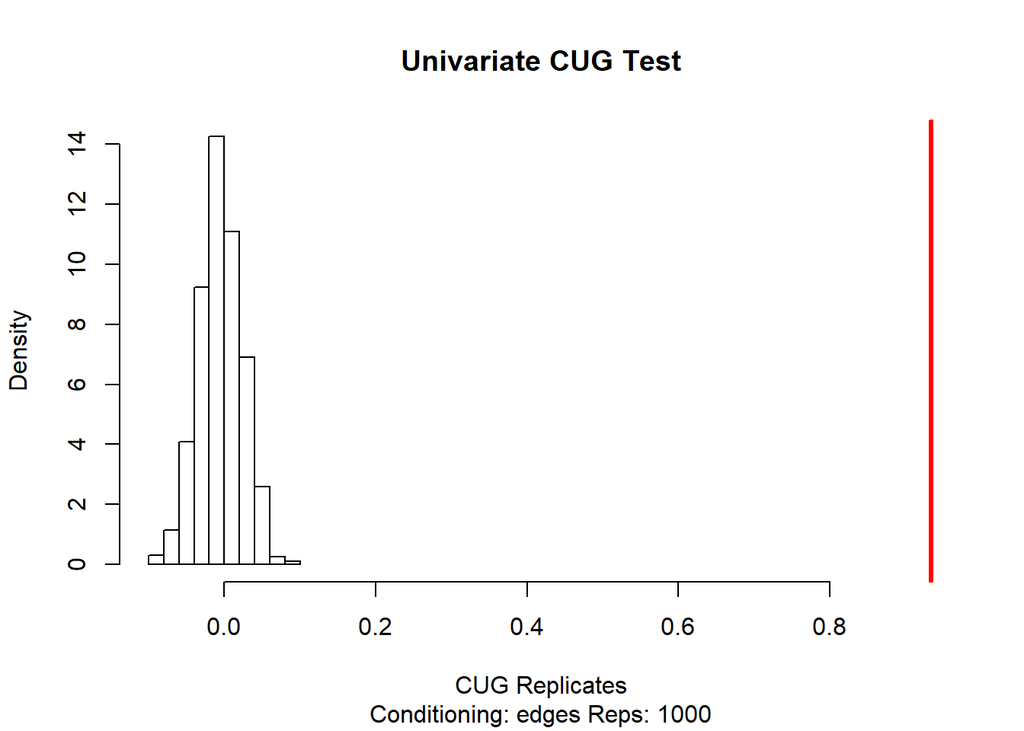

```r
plot.cug.test(grade.cug)
```

```r
print.cug.test(grade.cug)
```

```
##
## Univariate Conditional Uniform Graph Test
##
## Conditioning Method: edges
## Graph Type:
## Diagonal Used: FALSE
## Replications: 1000
##
## Observed Value: 0.9335869
## Pr(X>=Obs): 0
## Pr(X<=Obs): 1
```

### QAP test

Assortativity test passes for QAP test also. High Assotativity for Grade than Gender. The nodes were not randomly assortative.

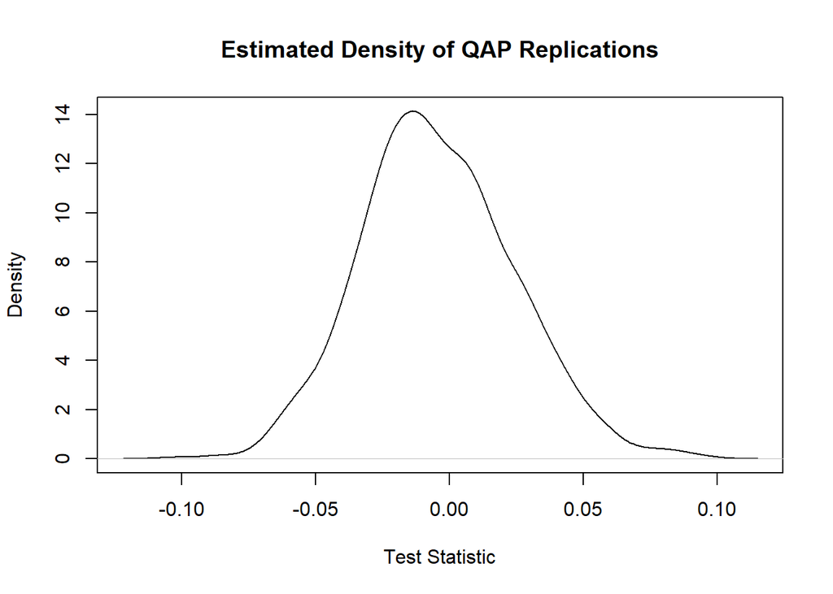

```r
# QAP test
sex.qap <- myqaptest(giant_1, assortativity, types1=attr.sex)
plot.qaptest(sex.qap)
```

```r
summary.qaptest(sex.qap)
```

```
##
## QAP Test Results
##
## Estimated p-values:
##  p(f(perm) >= f(d)): 0
##  p(f(perm) <= f(d)): 1
##
## Test Diagnostics:
##  Test Value (f(d)): 0.8271385
##  Replications: 1000
##  Distribution Summary:
##      Min:     -0.1026674
##      1stQ:    -0.02388405
##      Med:     -0.006676568
##      Mean:    -0.004457008
##      3rdQ:    0.01419206
##      Max:     0.09562436
```

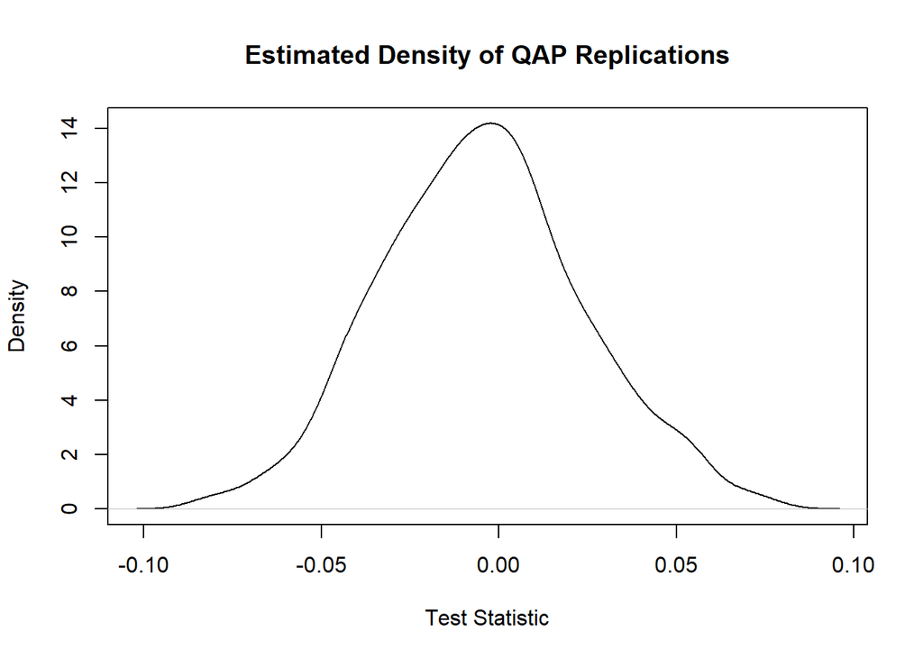

```r
grade.qap <- myqaptest(giant_1, assortativity, types1=attr.grade)
plot.qaptest(grade.qap)
```

```r
summary.qaptest(grade.qap)
```

```
##
## QAP Test Results
##
## Estimated p-values:
##  p(f(perm) >= f(d)): 0
##  p(f(perm) <= f(d)): 1
##
## Test Diagnostics:
##  Test Value (f(d)): 0.9335869
##  Replications: 1000
##  Distribution Summary:
##      Min:     -0.08325891
##      1stQ:    -0.02400758
##      Med:     -0.004993058
##      Mean:    -0.00465105
##      3rdQ:    0.01326326
##      Max:     0.0769853
```

### Conditional Probability For Grade Match, Male-Male, Female-Female, Male-Female Edges forming

Highest probability for Same grade nodes to form an edge

```r
edges <- c(1)
nodemixFF <- c(0,1,0,0)
nodemixFM <- c(1,0,0,0)
nodemixMM <- c(0,0,1,0)
nodematch.XO <-c(0,0,0,1)

cases <- c("F-M", "F-F", "M-M","Grade-Match")

cases.df <- data.frame(Case = cases, edges = edges,
                       nodemixFF,nodemixFM,nodemixMM,nodematch.XO)

logodds <- ga_1.m6$coef[1] * cases.df$edges +
  ga_1.m6$coef[2] * cases.df$nodemixFF +
  ga_1.m6$coef[3] * cases.df$nodemixFM +
  ga_1.m6$coef[4] * cases.df$nodemixMM +
  ga_1.m6$coef[5] * cases.df$nodematch.XO
cases.df$logodds <- logodds

cases.df$cond_prob <- invlogit(cases.df$logodds)
cases.df[order(cases.df$cond_prob),]
```

```
##          Case edges nodemixFF nodemixFM nodemixMM nodematch.XO    logodds
## 1         F-M     1         0         1         0            0 -4.7341445
## 2         F-F     1         1         0         0            0 -4.1174639
## 3         M-M     1         0         0         1            0 -3.9536443
## 4 Grade-Match     1         0         0         0            1  0.2547093
##     cond_prob
## 1 0.008713375
## 2 0.016024789
## 3 0.018823536
## 4 0.563335289
```

```r
##save(ga_1.m1,ga_1.m1.gof,ga_1.m2,ga_1.m2.gof,ga_1.m3,ga_1.m3.gof,ga_1.m4,ga_1.m4.gof,
##     ga_1.m5,ga_1.m5.gof,ga_1.m6,ga_1.m6.gof,
##     ga_2.m1,ga_2.m2,ga_2.m2.gof,ga_2.m3,ga_2.m3.gof,ga_2.m4,ga_2.m4.gof,
##     ga_2.m5,ga_2.m5.gof,ga_2.m6,ga_2.m6.gof,ga_2.m7,ga_2.m7.gof, file = "day1-model-ii.Rdata")
```